# Ice Cream Flavors Analysis

Dhivya Iyer

7/28/2021

Dataset from: [Kaggle](https://www.kaggle.com/tysonpo/ice-cream-dataset)

# Objective

Which types of ice cream should we sell in our convenience store for maximum customer satisfaction?

# Set up my environment

## Load packages

```r
library("tidyverse")
```

```r
library("ggplot2")
library("lubridate")
library("dplyr")
```

# Prepare data

## Upload datasets from csv files

```r
products<-read_csv("products.csv")
```

# Proccess data

## Select only relevant columns

```r
products<-products %>%
  select(-description) %>%
  select(-subhead)
head(products)
```

```
## # A tibble: 6 x 6
##   brand key   name                      rating rating_count ingredients
##   <chr> <chr> <chr>                      <dbl>        <dbl> <chr>
## 1 bj    0_bj  Salted Caramel Core          3.7          208 CREAM, SKIM MILK, L~
## 2 bj    1_bj  Netflix & Chilll'd™          4            127 CREAM, SKIM MILK, L~
## 3 bj    2_bj  Chip Happens                 4.7          130 CREAM, LIQUID SUGAR~
## 4 bj    3_bj  Cannoli                      3.6           70 CREAM, SKIM MILK, L~
## 5 bj    4_bj  Gimme S’more!™               4.5          281 CREAM, SKIM MILK, W~
## 6 bj    5_bj  Peanut Butter Half Baked®    4.9           14 CREAM, LIQUID SUGAR~
```

## Drop rows with NA values

```r
products<-drop_na(products)
```

# Analyze data

## Sort the ice cream flavors by rating and then by rating_count (more ratings mean that the ice cream flavor is more popular)

```r
products_by_rating<-products %>%
  arrange(desc(rating_count)) %>%
  arrange(desc(rating))
head(products_by_rating)
```

```
## # A tibble: 6 x 6
##   brand key   name              rating rating_count ingredients
##   <chr> <chr> <chr>              <dbl>        <dbl> <chr>
## 1 hd    31_hd Honey Salted Car~      5          103 CREAM, SKIM MILK, SUGAR, SW~
## 2 hd    63_hd Vanilla Caramel ~      5           32 CREAM, SKIM MILK, SUGAR, SW~
## 3 bj    29_bj Ice Cream Sammie       5           31 CREAM, SKIM MILK, LIQUID SU~
## 4 hd    43_hd Peppermint Bark ~      5           31 WHITE CHOCOLATE ICE CREAM (~
## 5 hd    14_hd Chocolate Fudge ~      5           22 WATER, SUGAR, CORN SYRUP, C~
## 6 hd    44_hd Peppermint Bark ~      5            8 WHITE CHOCOLATE ICE CREAM: ~
```

## Get the best ice cream flavors

The histogram shows that the median rating of ice cream flavors is 4.4

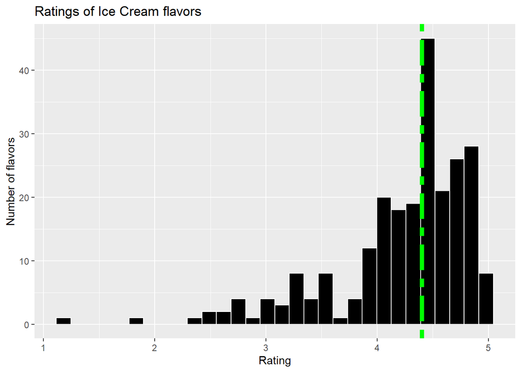

```r
median_rating=median(products$rating)
ggplot(products)+
  geom_histogram(aes(x=rating),color="white",fill="black")+
  geom_vline(aes(xintercept=median_rating),color="green",size=2,linetype="twodash")+
  labs(title="Ratings of Ice Cream flavors",x="Rating",y="Number of flavors")
```

Get the third quartile of the flavors by rating

```r
quantile(products$rating)
```

```
##   0%  25%  50%  75% 100%
##  1.2  4.0  4.4  4.7  5.0
```

So we should only use the ice cream flavors that have a rating of 4.7 or higher.

```r
best_products<-filter(products_by_rating,rating>=4.7)
best_products %>%
  select(brand,name) %>%
  head(12)
```

```
## # A tibble: 12 x 2
##    brand   name
##    <chr>   <chr>
##  1 hd      Honey Salted Caramel Almond Ice Cream
##  2 hd      Vanilla Caramel White Chocolate TRIO CRISPY LAYERS
##  3 bj      Ice Cream Sammie
##  4 hd      Peppermint Bark Ice Cream
##  5 hd      Chocolate Fudge Non-Dairy Bar
##  6 hd      Peppermint Bark Ice Cream Bar
##  7 bj      Chocolate Peanut Butter Split
##  8 breyers OREO® Snack Cups 10ct
##  9 hd      White Chocolate Raspberry Truffle Ice Cream
## 10 hd      Chocolate Ice Cream
## 11 bj      Peanut Butter World®
## 12 bj      New York Super Fudge Chunk®
```

If we only sell the top 12 flavors from this list, customers will feel that there are not enough options for the brand of ice cream. Instead, let’s find how the ratings of the ice cream from different brands compare to each other.

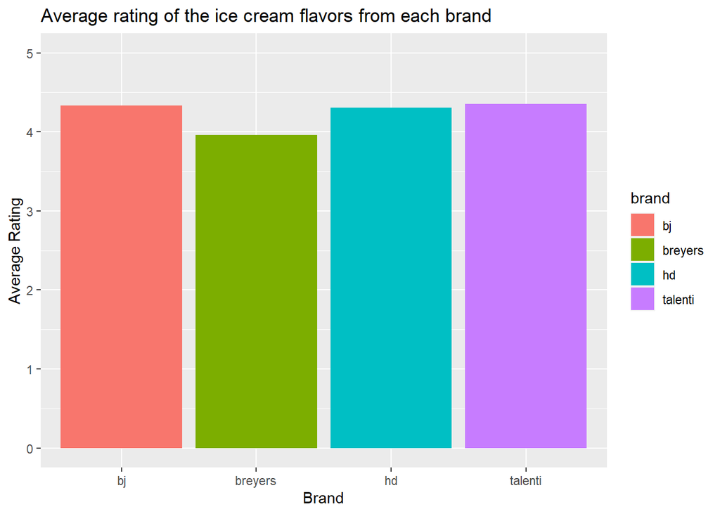

```r
avg_rating_by_company<-products %>%
  group_by(brand) %>%
  summarize(avg_rating=mean(rating))
ggplot(avg_rating_by_company)+
  geom_bar(stat="identity",aes(x=brand,y=avg_rating,fill=brand))+
  scale_y_continuous(limit=c(0,5))+
  labs(title="Average rating of the ice cream flavors from each brand",x="Brand",y="Average Rating")
```

All of these brands have a similar average rating so we should have ice cream from each brand.

## Get the best flavors from each brand

Let’s get the top 3 flavors from each brand.

```r
best_productshd <- best_products %>%
  filter(brand=="hd") %>%
  select(brand,name,rating) %>%
  head(3)
best_productsbj <- best_products %>%
  filter(brand=="bj") %>%
  select(brand,name,rating) %>%
  head(3)
best_productsb <- best_products %>%
  filter(brand=="breyers") %>%
  select(brand,name,rating) %>%
  head(3)
best_productst <- best_products %>%
  filter(brand=="talenti") %>%
  select(brand,name,rating) %>%
  head(3)
best_products_by_company=rbind(best_productshd,best_productsbj,best_productsb,best_productst)
```

Now we have the best flavors from each company.

# Conclusion

We should include the following flavors in our new convenience store to ensure the best customer satisfaction:

```r
head(best_products_by_company,12)
```

```
## # A tibble: 12 x 3
##    brand   name                                               rating
##    <chr>   <chr>                                               <dbl>
##  1 hd      Honey Salted Caramel Almond Ice Cream                 5
##  2 hd      Vanilla Caramel White Chocolate TRIO CRISPY LAYERS    5
##  3 hd      Peppermint Bark Ice Cream                             5
##  4 bj      Ice Cream Sammie                                      5
##  5 bj      Chocolate Peanut Butter Split                         5
##  6 bj      Peanut Butter World®                                  4.9
##  7 breyers OREO® Snack Cups 10ct                                 5
##  8 breyers Chocolate Snack Cups 10ct                             4.9
##  9 breyers No Sugar Added Caramel Swirl                          4.9
## 10 talenti CARAMEL APPLE PIE GELATO                              4.8
## 11 talenti COCONUT ALMOND CHOCOLATE GELATO                       4.8
## 12 talenti BELGIAN CHOCOLATE GELATO                              4.8
```